# FinalProjectDemo

Nabina Khadka

2023-04-27

# INTRODUCTION

Recently, people have started to go into Electric Vehicles(EVs). However, the old fashioned gas vehicles are still popular but since EVs are gaining more customers, hybrid cars are also being introduced. For my data analysis project, I am trying to gather information about the total EVs registered in Washington State Department of Licensing(DOL). The EVs are of two categories - Battery EVs and Plug-in Hybrid EVs.

# DATA SOURCE

The publisher of the data is data.wa.gov.

https://catalog.data.gov/dataset/electric-vehicle-population-data

The data set has 124,716 entries under 17 total columns. There are few columns that are missing so the total accuracy of the data set cannot be determined. In order to get more precise analysis, the NA value columns needs to be removed.

# Package and Data Loading

Let’s include the packages that we need

```r
library(ggplot2)
library(dplyr)
library(tidyverse)
library(readr)
```

```r
Sample_Data <- read_csv("Electric_Vehicle_Population_Data.csv")
str(Sample_Data)
```

```
## spc_tbl_ [124,716 × 17] (S3: spec_tbl_df/tbl_df/tbl/data.frame)
##  $ VIN (1-10)                                       : chr [1:124716] "5YJ3E1EB4L" "5YJ3E1EA7K" "7JRBR0FL9M" "5YJXCBE21K" ...
##  $ County                                           : chr [1:124716] "Yakima" "San Diego" "Lane" "Yakima" ...
##  $ City                                             : chr [1:124716] "Yakima" "San Diego" "Eugene" "Yakima" ...
##  $ State                                            : chr [1:124716] "WA" "CA" "OR" "WA" ...
##  $ Postal Code                                      : num [1:124716] 98908 92101 97404 98908 98021 ...
##  $ Model Year                                       : num [1:124716] 2020 2019 2021 2019 2017 ...
##  $ Make                                             : chr [1:124716] "TESLA" "TESLA" "VOLVO" "TESLA" ...
##  $ Model                                            : chr [1:124716] "MODEL 3" "MODEL 3" "S60" "MODEL X" ...
##  $ Electric Vehicle Type                            : chr [1:124716] "Battery Electric Vehicle (BEV)" "Battery Electric Vehicle (BEV)" "Plug-in Hybrid Electric Vehicle (PHEV)" "Battery Electric Vehicle (BEV)" ...
##  $ Clean Alternative Fuel Vehicle (CAFV) Eligibility: chr [1:124716] "Clean Alternative Fuel Vehicle Eligible" "Clean Alternative Fuel Vehicle Eligible" "Not eligible due to low battery range" "Clean Alternative Fuel Vehicle Eligible" ...
##  $ Electric Range                                   : num [1:124716] 322 220 22 289 14 84 215 10 75 26 ...
##  $ Base MSRP                                        : num [1:124716] 0 0 0 0 0 0 0 0 0 0 ...
##  $ Legislative District                             : num [1:124716] 14 NA NA 14 1 38 23 14 26 26 ...
##  $ DOL Vehicle ID                                   : num [1:124716] 1.27e+08 2.67e+08 1.45e+08 4.77e+08 1.06e+08 ...
##  $ Vehicle Location                                 : chr [1:124716] "POINT (-120.56916 46.58514)" "POINT (-117.16171 32.71568)" "POINT (-123.12802 44.09573)" "POINT (-120.56916 46.58514)" ...
##  $ Electric Utility                                 : chr [1:124716] "PACIFICORP" NA NA "PACIFICORP" ...
##  $ 2020 Census Tract                                : chr [1:124716] "53077000904" "06073005102" "41039002401" "53077000401" ...
##  - attr(*, "spec")=
##   .. cols(
##   ..   `VIN (1-10)` = col_character(),
##   ..   County = col_character(),
##   ..   City = col_character(),
##   ..   State = col_character(),
##   ..   `Postal Code` = col_double(),
##   ..   `Model Year` = col_double(),
##   ..   Make = col_character(),
##   ..   Model = col_character(),
##   ..   `Electric Vehicle Type` = col_character(),
##   ..   `Clean Alternative Fuel Vehicle (CAFV) Eligibility` = col_character(),
##   ..   `Electric Range` = col_double(),
##   ..   `Base MSRP` = col_double(),
##   ..   `Legislative District` = col_double(),
##   ..   `DOL Vehicle ID` = col_double(),
##   ..   `Vehicle Location` = col_character(),
##   ..   `Electric Utility` = col_character(),
##   ..   `2020 Census Tract` = col_character()
##   .. )
##  - attr(*, "problems")=<externalptr>
```

```r
summary(Sample_Data)
```

```
##   VIN (1-10)           County              City              State
##  Length:124716      Length:124716      Length:124716      Length:124716
##  Class :character   Class :character   Class :character   Class :character
##  Mode  :character   Mode  :character   Mode  :character   Mode  :character
##
##
##
##
##   Postal Code      Model Year       Make              Model
##  Min.   : 1730   Min.   :1997   Length:124716      Length:124716
##  1st Qu.:98052   1st Qu.:2018   Class :character   Class :character
##  Median :98121   Median :2020   Mode  :character   Mode  :character
##  Mean   :98164   Mean   :2019
##  3rd Qu.:98370   3rd Qu.:2022
##  Max.   :99701   Max.   :2023
##  NA's   :2
##  Electric Vehicle Type Clean Alternative Fuel Vehicle (CAFV) Eligibility
##  Length:124716         Length:124716
##  Class :character      Class :character
##  Mode  :character      Mode  :character
##
##
##
##
##  Electric Range     Base MSRP      Legislative District DOL Vehicle ID
##  Min.   :  0.00   Min.   :     0   Min.   : 1.00        Min.   :     4385
##  1st Qu.:  0.00   1st Qu.:     0   1st Qu.:18.00        1st Qu.:154101503
##  Median : 25.00   Median :     0   Median :34.00        Median :199555765
##  Mean   : 79.47   Mean   :  1556   Mean   :29.66        Mean   :204078955
##  3rd Qu.:200.00   3rd Qu.:     0   3rd Qu.:43.00        3rd Qu.:227516509
##  Max.   :337.00   Max.   :845000   Max.   :49.00        Max.   :479254772
##                                    NA's   :297
##  Vehicle Location   Electric Utility   2020 Census Tract
##  Length:124716      Length:124716      Length:124716
##  Class :character   Class :character   Class :character
##  Mode  :character   Mode  :character   Mode  :character
##
##
##
##
```

# CLEANING DATA

```r
data <- Sample_Data %>%
  rename("Vehicle" ="Make",
          "Year" ="Model Year"  ,
          "VehicleType" = "Electric Vehicle Type"  ,
          "Range"="Electric Range") %>%
  select(County, City , State , Vehicle , Model , Year , VehicleType, Range)
```

```r
data <- data %>%
  drop_na()

head(data)
```

```
## # A tibble: 6 × 8
##   County    City      State Vehicle Model    Year VehicleType              Range
##   <chr>     <chr>     <chr> <chr>   <chr>   <dbl> <chr>                    <dbl>
## 1 Yakima    Yakima    WA    TESLA   MODEL 3  2020 Battery Electric Vehicl…   322
## 2 San Diego San Diego CA    TESLA   MODEL 3  2019 Battery Electric Vehicl…   220
## 3 Lane      Eugene    OR    VOLVO   S60      2021 Plug-in Hybrid Electric…    22
## 4 Yakima    Yakima    WA    TESLA   MODEL X  2019 Battery Electric Vehicl…   289
## 5 Snohomish Bothell   WA    BMW     X5       2017 Plug-in Hybrid Electric…    14
## 6 Snohomish Everett   WA    NISSAN  LEAF     2015 Battery Electric Vehicl…    84
```

```r
summary(data)
```

```
##     County              City              State             Vehicle
##  Length:124533      Length:124533      Length:124533      Length:124533
##  Class :character   Class :character   Class :character   Class :character
##  Mode  :character   Mode  :character   Mode  :character   Mode  :character
##
##
##
##     Model                Year      VehicleType            Range
##  Length:124533      Min.   :1997   Length:124533      Min.   :  0.00
##  Class :character   1st Qu.:2018   Class :character   1st Qu.:  0.00
##  Mode  :character   Median :2020   Mode  :character   Median : 25.00
##                     Mean   :2019                      Mean   : 79.59
##                     3rd Qu.:2022                      3rd Qu.:200.00
##                     Max.   :2023                      Max.   :337.00
```

# GETTING TO LEARN ABOUT THE DATA

1. Which brand has the most popularity gained over the year?
2. Estimate the electric range of the most popular vehicle brand.

# Popularity gained over the year

Let us find out the brands that we have and how their popularity has been growing over the years.

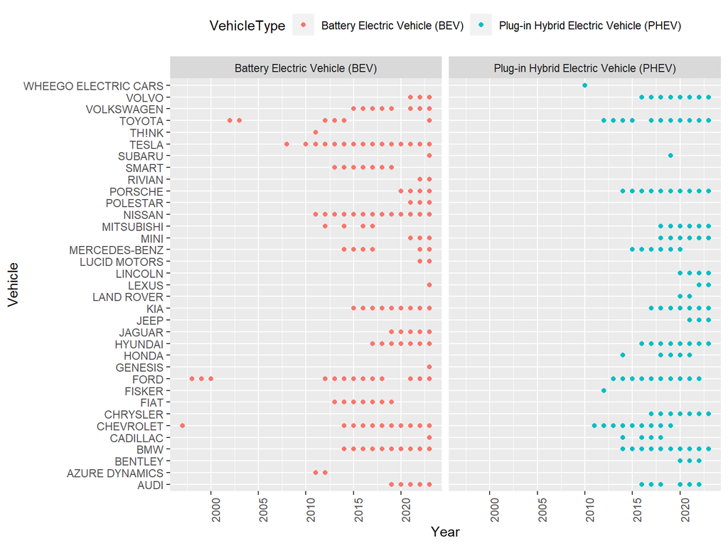

```r
ggplot(data , aes(x = Year , y = Vehicle  , color = VehicleType)) +
  geom_point() +
  theme(axis.text.x = element_text(angle = 90) , legend.position="top") +
  facet_grid(~VehicleType)
```

```r
pop <- data %>%
  filter(Vehicle %in% c('TESLA' ,'NISSAN' ,'KIA' ,'CHEVROLET','BMW','AUDI'))

head(pop)
```

```
## # A tibble: 6 × 8
##   County    City      State Vehicle Model    Year VehicleType              Range
##   <chr>     <chr>     <chr> <chr>   <chr>   <dbl> <chr>                    <dbl>
## 1 Yakima    Yakima    WA    TESLA   MODEL 3  2020 Battery Electric Vehicl…   322
## 2 San Diego San Diego CA    TESLA   MODEL 3  2019 Battery Electric Vehicl…   220
## 3 Yakima    Yakima    WA    TESLA   MODEL X  2019 Battery Electric Vehicl…   289
## 4 Snohomish Bothell   WA    BMW     X5       2017 Plug-in Hybrid Electric…    14
## 5 Snohomish Everett   WA    NISSAN  LEAF     2015 Battery Electric Vehicl…    84
## 6 Kitsap    Poulsbo   WA    TESLA   MODEL 3  2018 Battery Electric Vehicl…   215
```

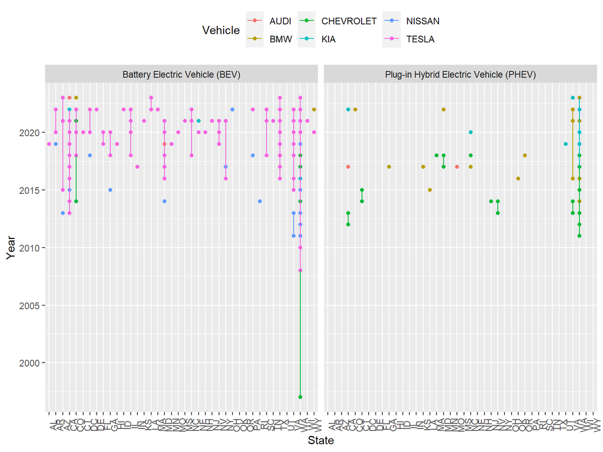

```r
ggplot(pop , aes(x = State , y = Year  , color = Vehicle)) +
  geom_point() +
  geom_line() +
  theme(axis.text.x = element_text(angle = 90),legend.position="top") +
  facet_grid(~VehicleType)
```

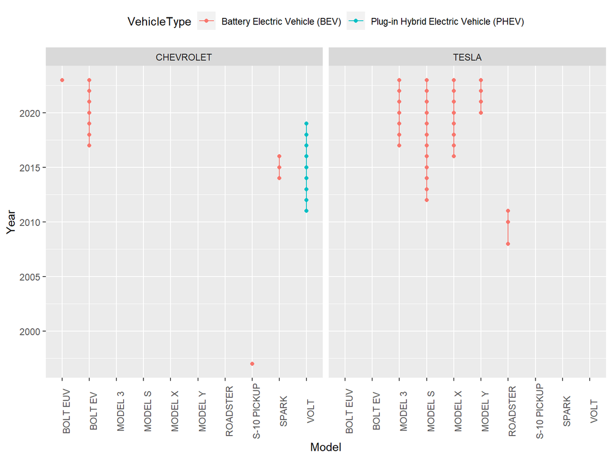

```r
WA_data <- data %>%
  filter(Vehicle %in% c('TESLA' ,'CHEVROLET'),
         State %in% c('WA'))

ggplot(WA_data , aes(x = Model , y = Year  , color = VehicleType)) +
  geom_point() +
  geom_line() +
  theme(axis.text.x = element_text(angle = 90), legend.position="top") +
  facet_grid(~Vehicle)
```

# Electric range of the most popular vehicle brand.

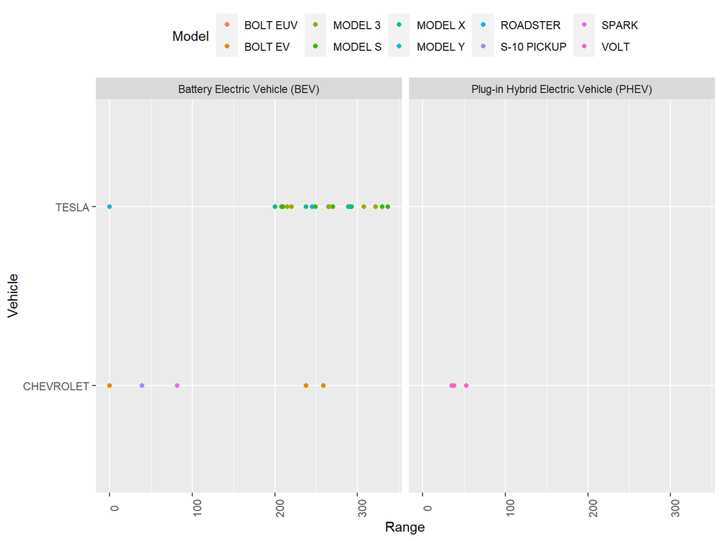

```r
ggplot(WA_data , aes(x = Range , y = Vehicle  , color = Model)) +
  geom_point() +
  theme(axis.text.x = element_text(angle = 90) , legend.position="top") +
  facet_grid(~VehicleType)
```

```r
Tesla <- WA_data %>%
  filter(Vehicle %in% c('TESLA'),
         State %in% c('WA') ,
         VehicleType %in% c('Battery Electric Vehicle (BEV)'))

head(Tesla)
```

```
## # A tibble: 6 × 8
##   County    City     State Vehicle Model    Year VehicleType               Range
##   <chr>     <chr>    <chr> <chr>   <chr>   <dbl> <chr>                     <dbl>
## 1 Yakima    Yakima   WA    TESLA   MODEL 3  2020 Battery Electric Vehicle…   322
## 2 Yakima    Yakima   WA    TESLA   MODEL X  2019 Battery Electric Vehicle…   289
## 3 Kitsap    Poulsbo  WA    TESLA   MODEL 3  2018 Battery Electric Vehicle…   215
## 4 Snohomish Mukilteo WA    TESLA   MODEL S  2017 Battery Electric Vehicle…   210
## 5 Thurston  Olympia  WA    TESLA   MODEL 3  2018 Battery Electric Vehicle…   215
## 6 Thurston  Olympia  WA    TESLA   MODEL X  2017 Battery Electric Vehicle…   200
```

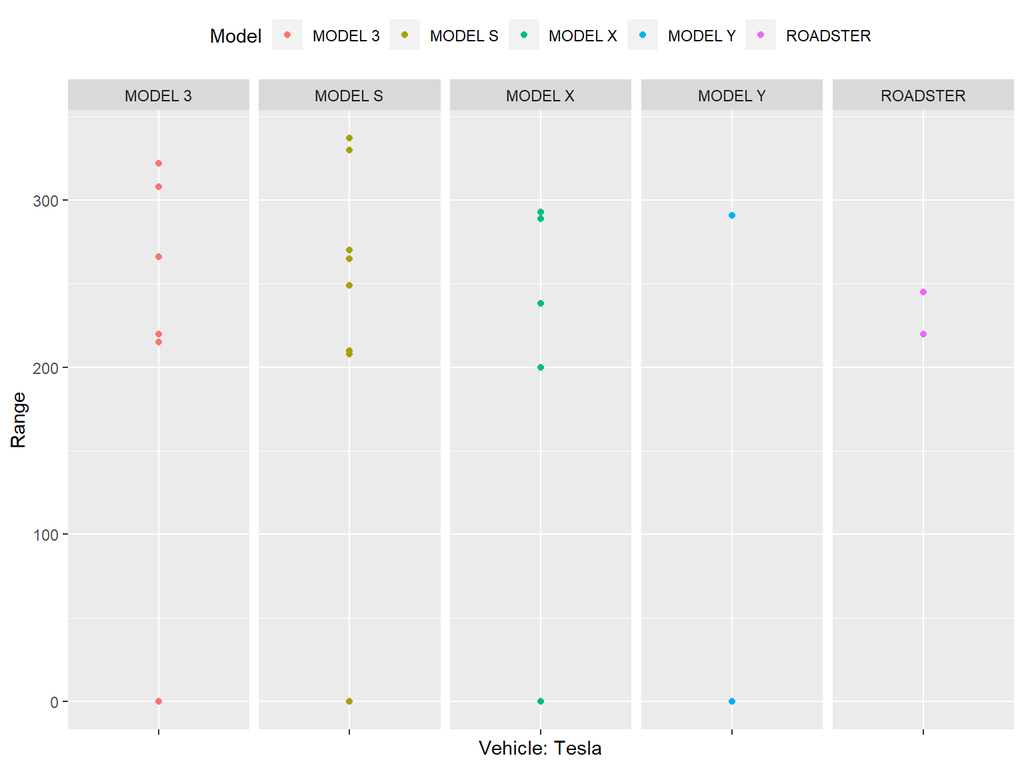

```r
ggplot(Tesla , aes(x = Vehicle , y = Range  , color = Model)) +
  geom_point() +
  facet_grid(~Model)+
  labs(x = "Vehicle: Tesla", y = "Range") +
  theme(axis.text.x=element_blank(),legend.position="top")
```

Let’s animate it for fun.

```r
library(gganimate)
```

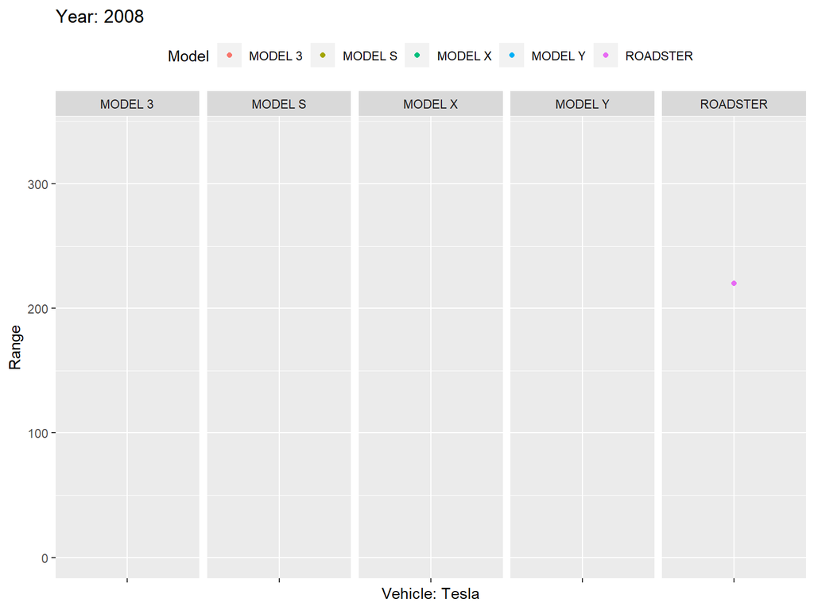

```r
ggplot(Tesla , aes(x = Vehicle , y = Range  , color = Model)) +
  geom_point() +
  facet_grid(~Model)+
  theme(axis.text.x=element_blank(),legend.position="top")+
  transition_time(Year) +
  labs(title = "Year: {as.integer(frame_time)}" , x = "Vehicle: Tesla", y = "Range")+
  shadow_wake(wake_length = 0.1, alpha = FALSE)
```

# Conclusion

Here, we can see that over the year, the electric range has reached above 300 by 2023 and TESLA MODEL S has gained the most popularity.